# netflix

```python
import pandas as pd
import numpy as np
import matplotlib.pyplot as plt
import seaborn as sns
import datetime
import geopandas as gpd
import warnings

pd.options.mode.chained_assignment = None
warnings.filterwarnings("ignore", category=DeprecationWarning)
```

### Load data

```python
df = pd.read_csv('netflix_titles.csv')
df.head(2)
```

|  | show_id | type | title | director | cast | country | date_added | release_year | rating | duration | listed_in | description |
| --- | --- | --- | --- | --- | --- | --- | --- | --- | --- | --- | --- | --- |
| 0 | s1 | Movie | Dick Johnson Is Dead | Kirsten Johnson | NaN | United States | September 25, 2021 | 2020 | PG-13 | 90 min | Documentaries | As her father nears the end of his life, filmm... |
| 1 | s2 | TV Show | Blood & Water | NaN | Ama Qamata, Khosi Ngema, Gail Mabalane, Thaban... | South Africa | September 24, 2021 | 2021 | TV-MA | 2 Seasons | International TV Shows, TV Dramas, TV Mysteries | After crossing paths at a party, a Cape Town t... |

### Clean

```python
print('before cleaning NaN/duplicated: \n')
print('rows:', df.shape[0])
print('columns:', df.shape[1])
```

```
before cleaning NaN/duplicated:

rows: 8807
columns: 12
```

```python
df.info()
```

```
<class 'pandas.core.frame.DataFrame'>
RangeIndex: 8807 entries, 0 to 8806
Data columns (total 12 columns):
 #   Column        Non-Null Count  Dtype
---  ------        --------------  -----
 0   show_id       8807 non-null   object
 1   type          8807 non-null   object
 2   title         8807 non-null   object
 3   director      6173 non-null   object
 4   cast          7982 non-null   object
 5   country       7976 non-null   object
 6   date_added    8797 non-null   object
 7   release_year  8807 non-null   int64
 8   rating        8803 non-null   object
 9   duration      8804 non-null   object
 10  listed_in     8807 non-null   object
 11  description   8807 non-null   object
dtypes: int64(1), object(11)
memory usage: 825.8+ KB
```

```python
dupe = df.duplicated().sum()
print('duplicated entries:', dupe)
```

```
duplicated entries: 0
```

```python
missing = df.isna().sum()
print('Missing values: \n')
print(missing[missing>0])
```

```
Missing values:

director      2634
cast           825
country        831
date_added      10
rating           4
duration         3
dtype: int64
```

```python
df['director'].fillna('Unknown',inplace = True)
df['cast'].fillna('Unknown',inplace = True)
df['country'].fillna('Unknown',inplace = True)
df.dropna(subset=['date_added','rating','duration'],inplace=True)
```

```python
missing_after = df.isna().sum()
print('Missing values after cleaning: \n')
print(missing_after)
```

```
Missing values after cleaning:

show_id         0
type            0
title           0
director        0
cast            0
country         0
date_added      0
release_year    0
rating          0
duration        0
listed_in       0
description     0
dtype: int64
```

```python
print('after cleaning NaN/duplicated: \n')
print('rows:', df.shape[0])
print('columns:', df.shape[1])
```

```
after cleaning NaN/duplicated:

rows: 8790
columns: 12
```

### Add columns/Remove unnecessary columns

```python
df['description_length'] = df['description'].str.len()
df.head(2)
```

|  | show_id | type | title | director | cast | country | date_added | release_year | rating | duration | listed_in | description | description_length |
| --- | --- | --- | --- | --- | --- | --- | --- | --- | --- | --- | --- | --- | --- |
| 0 | s1 | Movie | Dick Johnson Is Dead | Kirsten Johnson | Unknown | United States | September 25, 2021 | 2020 | PG-13 | 90 min | Documentaries | As her father nears the end of his life, filmm... | 152 |
| 1 | s2 | TV Show | Blood & Water | Unknown | Ama Qamata, Khosi Ngema, Gail Mabalane, Thaban... | South Africa | September 24, 2021 | 2021 | TV-MA | 2 Seasons | International TV Shows, TV Dramas, TV Mysteries | After crossing paths at a party, a Cape Town t... | 147 |

```python
df.shape
```

```
(8790, 13)
```

```python
df.nunique()
```

```
show_id               8790
type                     2
title                 8790
director              4527
cast                  7679
country                749
date_added            1765
release_year            74
rating                  14
duration               220
listed_in              513
description           8758
description_length     104
dtype: int64
```

```python
df.columns
```

```
Index(['show_id', 'type', 'title', 'director', 'cast', 'country', 'date_added',
       'release_year', 'rating', 'duration', 'listed_in', 'description',
       'description_length'],
      dtype='object')
```

```python
#remove unnecessary columns
df = df[[ 'type', 'director', 'cast', 'country', 'date_added',
       'release_year', 'rating', 'duration', 'listed_in', 'description',
       'description_length']]
df.head(2)
```

|  | type | director | cast | country | date_added | release_year | rating | duration | listed_in | description | description_length |
| --- | --- | --- | --- | --- | --- | --- | --- | --- | --- | --- | --- |
| 0 | Movie | Kirsten Johnson | Unknown | United States | September 25, 2021 | 2020 | PG-13 | 90 min | Documentaries | As her father nears the end of his life, filmm... | 152 |
| 1 | TV Show | Unknown | Ama Qamata, Khosi Ngema, Gail Mabalane, Thaban... | South Africa | September 24, 2021 | 2021 | TV-MA | 2 Seasons | International TV Shows, TV Dramas, TV Mysteries | After crossing paths at a party, a Cape Town t... | 147 |

```python
df.info()
```

```
<class 'pandas.core.frame.DataFrame'>
Int64Index: 8790 entries, 0 to 8806
Data columns (total 11 columns):
 #   Column              Non-Null Count  Dtype
---  ------              --------------  -----
 0   type                8790 non-null   object
 1   director            8790 non-null   object
 2   cast                8790 non-null   object
 3   country             8790 non-null   object
 4   date_added          8790 non-null   object
 5   release_year        8790 non-null   int64
 6   rating              8790 non-null   object
 7   duration            8790 non-null   object
 8   listed_in           8790 non-null   object
 9   description         8790 non-null   object
 10  description_length  8790 non-null   int64
dtypes: int64(2), object(9)
memory usage: 824.1+ KB
```

```python
df['date_added'] = df['date_added'].str.strip()
df['date_added'] = pd.to_datetime(df['date_added'],format = '%B %d, %Y')
df.info()
```

```
<class 'pandas.core.frame.DataFrame'>
Int64Index: 8790 entries, 0 to 8806
Data columns (total 11 columns):
 #   Column              Non-Null Count  Dtype
---  ------              --------------  -----
 0   type                8790 non-null   object
 1   director            8790 non-null   object
 2   cast                8790 non-null   object
 3   country             8790 non-null   object
 4   date_added          8790 non-null   datetime64[ns]
 5   release_year        8790 non-null   int64
 6   rating              8790 non-null   object
 7   duration            8790 non-null   object
 8   listed_in           8790 non-null   object
 9   description         8790 non-null   object
 10  description_length  8790 non-null   int64
dtypes: datetime64[ns](1), int64(2), object(8)
memory usage: 824.1+ KB
```

```python
df.head(2)
```

|  | type | director | cast | country | date_added | release_year | rating | duration | listed_in | description | description_length |
| --- | --- | --- | --- | --- | --- | --- | --- | --- | --- | --- | --- |
| 0 | Movie | Kirsten Johnson | Unknown | United States | 2021-09-25 | 2020 | PG-13 | 90 min | Documentaries | As her father nears the end of his life, filmm... | 152 |
| 1 | TV Show | Unknown | Ama Qamata, Khosi Ngema, Gail Mabalane, Thaban... | South Africa | 2021-09-24 | 2021 | TV-MA | 2 Seasons | International TV Shows, TV Dramas, TV Mysteries | After crossing paths at a party, a Cape Town t... | 147 |

```python
df['added_date'] = df['date_added'].dt.day
df['added_month'] = df['date_added'].dt.month
df['added_year'] = df['date_added'].dt.year
```

### Visualization

```python
df.nunique()
```

```
type                     2
director              4527
cast                  7679
country                749
date_added            1713
release_year            74
rating                  14
duration               220
listed_in              513
description           8758
description_length     104
added_date              31
added_month             12
added_year              14
dtype: int64
```

**Which type contributed the most shows on Netflix?**

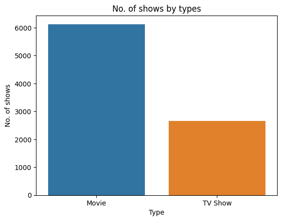

```
Most of the shows on Netflix are Movie with 6126 shows, contains about 69.69% overall.
```

```python
#GroupBy Type
df_type = df.groupby(by = 'type').agg(count = ('type','count')).reset_index()

#Identify highest values
most_type = df_type[df_type['count'] == df_type['count'].max()]['type'].values[0]
most_type_value = df_type[df_type['count'] == df_type['count'].max()]['count'].values[0]
most_type_pct = (most_type_value / df_type.sum()[1]) * 100

#Plot chart
sns.barplot(data=df_type, x='type', y='count')
plt.xlabel('Type')
plt.ylabel('No. of shows')
plt.title('No. of shows by types')
plt.show()

#Comment
print(f'Most of the shows on Netflix are {most_type} with {most_type_value} shows, contains about {most_type_pct:.2f}% overall.')
```

```python
#Filter 2 specific dataframe to see the duration of each
df_movie = df[df['type']=='Movie']
df_tvshow = df[df['type']=='TV Show']

#Convert dtype
df_movie['duration'] = df_movie['duration'].str.replace(' min', '')
df_movie['duration'] = df_movie['duration'].astype(int)

df_tvshow['duration'] = df_tvshow['duration'].str.replace(' Seasons', '').str.replace(' Season', '')
df_tvshow['duration'] = df_tvshow['duration'].astype(int)

#GroupBy duration
df_movie_duration = df_movie.groupby(by = 'duration').agg(count = ('duration','count')).reset_index()
df_tvshow_duration = df_tvshow.groupby(by = 'duration').agg(count = ('duration','count')).reset_index()
```

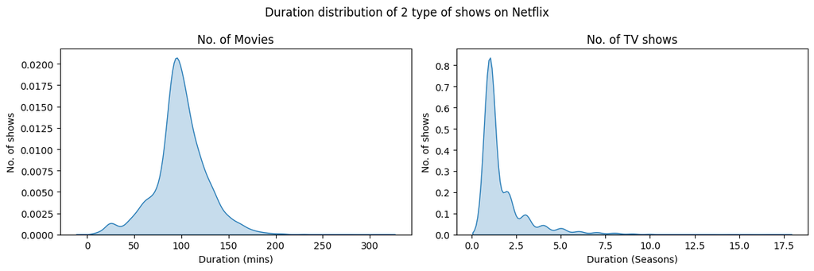

```
A good number of movies on Netflix are among the duration of 75-120 mins.
It is acceptable considering the fact that a fair amount of the users cannot
watch a movie in a too long time.

The fluctuation in the number of Seasons of TV shows on Netflix typically ranges from 1 to 2.
This reflects the stability and consistency in content delivery and is considered an acceptable
average figure in the entertainment industry.
```

```python
fig,axes = plt.subplots(1,2,figsize = (12,4))

#
sns.kdeplot(data = df_movie['duration']
            ,fill=True
            ,ax = axes[0])
axes[0].set_xlabel('Duration (mins)')
axes[0].set_ylabel('No. of shows')
axes[0].set_title('No. of Movies')

sns.kdeplot(data = df_tvshow['duration']
            ,fill=True
            ,ax = axes[1])
axes[1].set_xlabel('Duration (Seasons)')
axes[1].set_ylabel('No. of shows')
axes[1].set_title('No. of TV shows')

plt.suptitle('Duration distribution of 2 type of shows on Netflix')
plt.tight_layout()
plt.show()

#Comment
print(\
'A good number of movies on Netflix are among the duration of 75-120 mins.\n\
It is acceptable considering the fact that a fair amount of the users cannot\n\
watch a movie in a too long time.\n\
\n\
The fluctuation in the number of Seasons of TV shows on Netflix typically ranges from 1 to 2.\n\
This reflects the stability and consistency in content delivery and is considered an acceptable\n\
average figure in the entertainment industry.\n\
'
)
```

**Which rating are popular on Netflix?**

Here are the meanings of some of the abbreviations used in the context of age ratings and classifications for movies and TV shows:

1. TV-MA: This rating is for TV programs intended for mature audiences, typically aged 17 and older.
2. TV-14: This rating is for TV programs intended for viewers aged 14 and older, and they may contain content unsuitable for viewers under 14.
3. TV-PG: This is a rating for family-friendly TV programs, though there may be some content unsuitable for young children.
4. R: This rating is for movies suitable for viewers aged 17 and older, or they may contain content unsuitable for viewers under 17.
5. PG-13: This rating is for movies suitable for viewers aged 13 and older, or it may require adult guidance.
6. TV-Y7: TV programs for viewers aged 7 and older.
7. TV-Y: This rating is for TV programs suitable for all audiences, including children.
8. PG: This is a rating for family-friendly movies, although there may be some content unsuitable for young children.
9. TV-G: This is a rating for family-friendly TV programs, suitable for all audiences.
10. NR: "Not Rated," typically used for works that haven't gone through an official rating process.
11. G: This rating is for family-friendly movies, suitable for all audiences.
12. TV-Y7-FV: TV programs for viewers aged 7 and older, but they may contain more parental guidance.
13. NC-17: This rating is for movies suitable for viewers aged 17 and older, and it's stricter than an R rating.
14. UR: "Unrated," often used when a work has not been rated or to indicate uncertainty about the suitability for a specific audience.

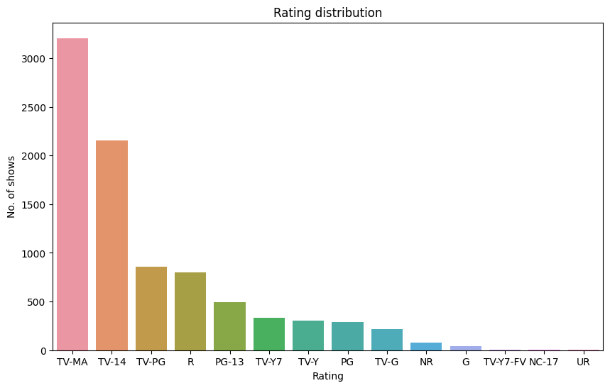

```
Most popular rating: TV-MA
Total no. of shows: 3205
```

```python
#GroupBy Rating
df_rating = df.groupby(by = 'rating').agg(counting = ('rating','count')).reset_index().sort_values(by = 'counting',ascending=False)

#Identify most popular rating
most_popular_rating = df_rating[df_rating['counting'] == df_rating['counting'].max()]['rating'].values[0]
most_popular_rating_value = df_rating[df_rating['counting'] == df_rating['counting'].max()]['counting'].values[0]

plt.figure(figsize=(10, 6))

#Rating distribution
sns.barplot(data = df_rating
            , x ='rating'
            , y ='counting')
plt.xlabel('Rating')
plt.ylabel('No. of shows')
plt.title('Rating distribution')

plt.show()

#Comment
print(f"Most popular rating: {most_popular_rating}")
print(f"Total no. of shows: {most_popular_rating_value}")
```

**Which is the "boom" year of Netflix?**

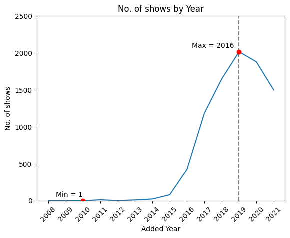

[output not shown]

```python
#GroupBy added_year
df_year = df.groupby(by = 'added_year').agg(counting = ('added_year','count')).reset_index().sort_values(by = 'added_year',ascending=True)

#Identify max/min count
max_count = max(df_year["counting"])
min_count = min(df_year["counting"])
max_year = df_year["added_year"][df_year["counting"].idxmax()]
min_year = df_year["added_year"][df_year["counting"].idxmin()]

#Plot chart
sns.lineplot(data = df_year
             ,x = 'added_year'
             ,y = 'counting')
plt.scatter(max_year, max_count, color='red', zorder=5)
plt.scatter(min_year, min_count, color='red', zorder=5, marker= 'o')
plt.text(max_year - 0.3, max_count + 50, f'Max = {max_count}', ha='right')
plt.text(min_year, min_count + 50, f'Min = {min_count}', ha='right')

plt.axvline(x=max_year, color='gray', linestyle='--', label=f'Max Year ({max_year})')

plt.xticks(df_year["added_year"])
plt.ylim(0,2500)
plt.xlabel("Added Year")
plt.ylabel("No. of shows")
plt.title("No. of shows by Year")
plt.xticks(rotation=45)

plt.show()

#Comment
print(\
f'It can be clearly seen that the No. of shows witness the lowest value at {min_count} in {min_year}.\n\
This number dramatically multiplied {max_count/min_count:.0f} times by the end of {max_year}.\n\
\n\
In 2019, due to the effect of COVID-19 epidemic, with people in many parts of the world restricted from leaving\n\
their homes and social activities, many users have increased their demand for online entertainment services. \n\
Netflix has benefited from this increase in demand for online movies and home entertainment.'
)
```

**Across each year, is there any different between months?**

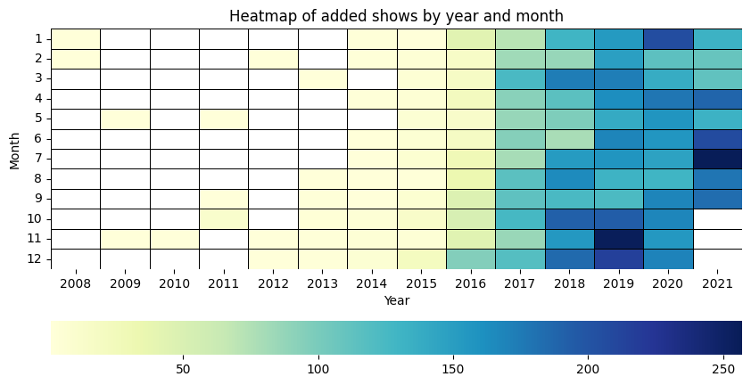

```
If the highest year - 2019 is considered, May, August and September were
the months when much less shows was on-air compared to the other months.

Therefore, selecting these months could increase the chances of success for a new show release on Netflix.
```

```python
#Create matrix for heatmap
release_heatmap = df.pivot_table(values = 'type'
                                ,index = 'added_month'
                                ,columns='added_year'
                                ,aggfunc='count')

#Plot heatmap
plt.figure(figsize=(10, 5))

ax = sns.heatmap(data = release_heatmap
            , cmap='YlGnBu'
            , xticklabels=release_heatmap.columns
            , yticklabels=release_heatmap.index
            , square=False
            , cbar_kws={'orientation': 'horizontal'}
            , linewidths= 0.5
            , linecolor='black'
            )
plt.xticks(rotation=0)
plt.yticks(rotation=0)
plt.xlabel('Year')
plt.ylabel('Month')
plt.title('Heatmap of added shows by year and month')
plt.show()

#Comment
print(\
'If the highest year - 2019 is considered, May, August and September were \n\
the months when much less shows was on-air compared to the other months.\n\
\n\
Therefore, selecting these months could increase the chances of success for a new show release on Netflix.'
)
```

**What are the top 10 categories having highest number of shows?**

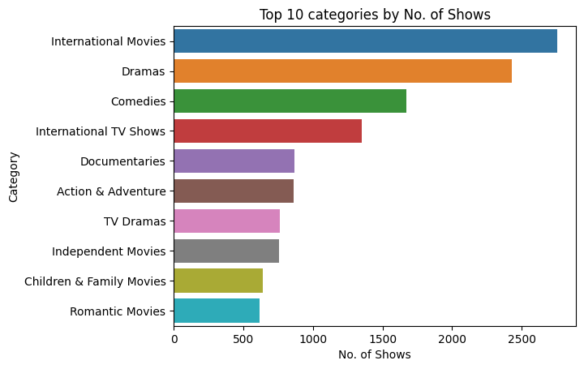

```
Netflix offers a diverse range of content categories, including International Movies, Dramas, Comedies, International TV shows, Documentaries, and more.
This diversity caters to a wide audience with varying preferences.

Netflix can use these data about categories to enhance its recommendation algorithms. Users who enjoy content in one category may receive recommendations
from related categories, increasing user engagement.

Moreover, Netflix can use this data for comparative analysis with other streaming platforms to make users understand how its content library compares in
terms of category distribution.
```

```python
#stacked listed_in
listed_in = df['listed_in'].str.split(pat = ', ',expand=True).apply(pd.Series).stack().reset_index(drop=True)
listed_in.name = 'category'

#top 10 categories
df_category = pd.DataFrame({'category': listed_in})
df_category_grpby = df_category.groupby(by = 'category').agg(count = ('category','count')).reset_index().sort_values(by = 'count',ascending=False).reset_index(drop=True)
df_top10_category = df_category_grpby.head(10)

#Plot chart
sns.barplot(data= df_top10_category
            ,y = 'category'
            ,x = 'count')

plt.xlabel('No. of Shows')
plt.ylabel('Category')
plt.title('Top 10 categories by No. of Shows')
plt.show()

#Comment
print(\
'Netflix offers a diverse range of content categories, including International Movies, Dramas, Comedies, International TV shows, Documentaries, and more.\n\
This diversity caters to a wide audience with varying preferences.\n\
\n\
Netflix can use these data about categories to enhance its recommendation algorithms. Users who enjoy content in one category may receive recommendations\n\
from related categories, increasing user engagement.\n\
\n\
Moreover, Netflix can use this data for comparative analysis with other streaming platforms to make users understand how its content library compares in\n\
terms of category distribution.\n\
'
)
```

**What are the top 10 directors having highest number of shows?**

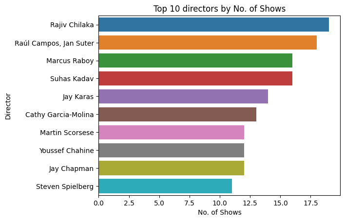

```
We can see that there were 5 directors who contributed the highest number of shows.
They are Rajiv Chilaka, Raúl Campos, Jan Suter, Marcus Raboy, Suhas Kadav, Jay Karas with the number of shows are 19, 18, 16, 16, 14, respectively.
```

```python
#Identify top 10 directors
df_director = df.groupby(by = 'director').agg(count = ('director','count')).reset_index().sort_values(by = 'count',ascending=False)
df_top10_director = df_director[df_director['director']!='Unknown'].reset_index(drop = True).head(10)

#Plot chart
sns.barplot(data= df_top10_director
            ,y = 'director'
            ,x = 'count')

plt.xlabel('No. of Shows')
plt.ylabel('Director')
plt.title('Top 10 directors by No. of Shows')
plt.show()

#Top 5 director name
director_name = ", ".join(director_name for director_name in df_top10_director['director'].head(5))
df_top10_director['count_text'] = df_top10_director['count'].astype(str)
director_value = ", ".join(director_value for director_value in df_top10_director['count_text'].head(5))

#Comment
print(f'We can see that there were 5 directors who contributed the highest number of shows.\n\
They are {director_name} with the number of shows are {director_value}, respectively.')
```

**Which country had the highest number of shows?**

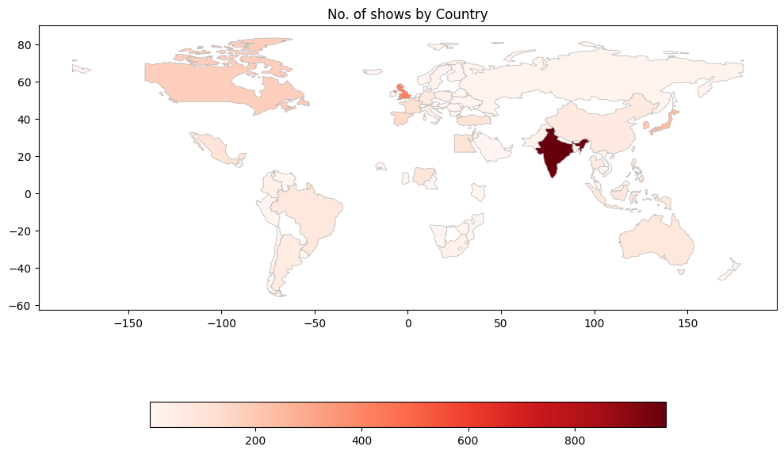

[output not shown]

```python
#GroupBy Country
df_country = df.groupby(by = 'country').agg(count = ('country','count')).reset_index().sort_values(by = 'count',ascending=False).reset_index(drop=True)
most_country = df_country[df_country['count'] == df_country['count'].max()]['country'].values[0]
most_country_value = df_country[df_country['count'] == df_country['count'].max()]['count'].values[0]

#Plot map
shapemap = gpd.datasets.get_path('naturalearth_lowres')
world = gpd.read_file(shapemap)
merged = world.set_index('name').join(pd.DataFrame(df_country).set_index('country'))

fig, ax = plt.subplots(1, 1, figsize=(10, 8))
merged.plot(column='count'
            , cmap='Reds'
            , linewidth=0.5
            , ax=ax
            , edgecolor='0.7'
            , legend=True
            , legend_kwds={'orientation': "horizontal"
                           , 'shrink': 0.7
                           }
            )
ax.set_title('No. of shows by Country')

plt.tight_layout()
plt.show()

#Comment
print(f'It can be seen that, the darkest color is {most_country} with the number of shows are {most_country_value}')
```

**Which are the most popular keywords in description?**

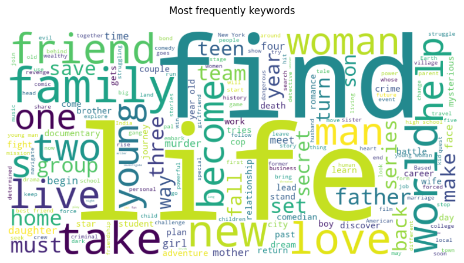

```
The below keywords are recorded to appear the most in the shows' description.

The Marketing team of Netflix can base on these keywords and compare with their social contents
to optimize their SEO contents, reduce costs for digital marketing
```

```python
from wordcloud import WordCloud

text = " ".join(description for description in df['description'])

wordcloud = WordCloud(width=800, height=400, background_color="white",colormap='viridis').generate(text)

#Plot chart
plt.figure(figsize=(10, 5))
plt.imshow(wordcloud, interpolation="bilinear")
plt.title('Most frequently keywords\n')
plt.axis("off")
plt.show()

#Comment
print(\
"The below keywords are recorded to appear the most in the shows' description.\n\
\n\
The Marketing team of Netflix can base on these keywords and compare with their social contents\n\
to optimize their SEO contents, reduce costs for digital marketing"
)
```